## 7.11 Add-on packages

The power of **ggplot2** is augmented further due to the availability of add-on packages. The remaining changes needed to put the finishing touches on our plot require the **ggthemes** and **ggrepel** packages.

The style of a **ggplot2** graph can be changed using the `theme` functions. Several themes are included as part of the **ggplot2** package. In fact, for most of the plots in this book, we use a function in the **dslabs** package that automatically sets a default theme:

```r
ds_theme_set()
```

Many other themes are added by the package **ggthemes**. Among those are the `theme_economist` theme that we used. After installing the package, you can change the style by adding a layer like this:

```r
install.packages("ggthemes")
library(ggthemes)
p + theme_economist()
```

You can see how some of the other themes look by simply changing the function. For instance, you might try the `theme_fivethirtyeight()` theme instead.

The final difference has to do with the position of the labels. In our plot, some of the labels fall on top of each other. The add-on package **ggrepel** includes a geometry that adds labels while ensuring that they don’t fall on top of each other. We simply change `geom_text` with `geom_text_repel`.

## 7.12 Putting it all together

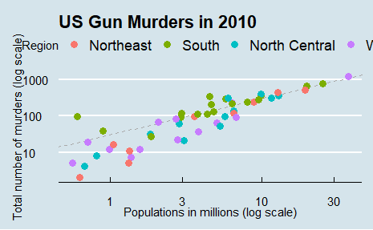

## 7.13 Quick plots with `qplot`

We have learned the powerful approach to generating visualization with ggplot. However, there are instances in which all we want is to make a quick plot of, for example, a histogram of the values in a vector, a scatter plot of the values in two vectors, or a boxplot using categorical and numeric vectors. We demonstrated how to generate these plots with `hist`, `plot`, and `boxplot`. However, if we want to keep consistent with the ggplot style, we can use the function `qplot`.

If we have values in two vectors, say:

```r
library(dslabs)
data(murders)
x <- log10(murders$population)
y <- murders$total
```

and we want to make a scatterplot with ggplot, we would have to type something like:

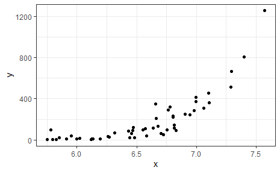

```r
data.frame(x = x, y = y) %>%
  ggplot(aes(x, y)) +
  geom_point()
```

This seems like too much code for such a simple plot. The `qplot` function sacrifices the flexibility provided by the `ggplot` approach, but allows us to generate a plot quickly.

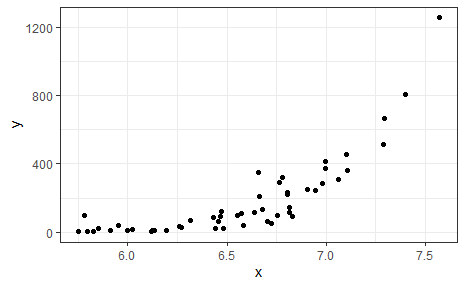

```r
qplot(x, y)
```

We will learn more about `qplot` in Section [8.16](https://rafalab.github.io/dsbook/distributions.html#other-geometries)

## 7.14 Grids of plots

There are often reasons to graph plots next to each other. The **gridExtra** package permits us to do that:

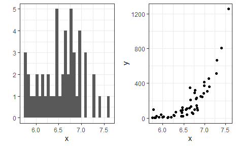

```r
library(gridExtra)
p1 <- qplot(x)
p2 <- qplot(x,y)
grid.arrange(p1, p2, ncol = 2)
```

## 7.15 Exercises

Start by loading the **dplyr** and **ggplot2** library as well as the `murders` and `heights` data.

```r
library(dplyr)
library(ggplot2)
library(dslabs)
data(heights)
data(murders)
```

1. With **ggplot2** plots can be saved as objects. For example we can associate a dataset with a plot object like this

```r
p <- ggplot(data = murders)
```

Because `data` is the first argument we don’t need to spell it out

```r
p <- ggplot(murders)
```

and we can also use the pipe:

```r
p <- murders %>% ggplot()
```

What is class of the object `p`?

```r
class(p)
```

```
[1] "gg"     "ggplot"
```

2. Remember that to print an object you can use the command `print` or simply type the object. Print the object p defined in exercise one and describe what you see.

```r
p
```

1. Nothing happens.
2. A blank slate plot.
3. A scatter plot.
4. A histogram.

**Answer: B**

3. Using the pipe `%>%`, create an object `p` but this time associated with the `heights` dataset instead of the `murders` dataset.

```r
p <- heights %>% ggplot()
```

4. What is the class of the object `p` you have just created?

```r
class(p)
```

```
[1] "gg"     "ggplot"
```

5. Now we are going to add a layers and the corresponding aesthetic mappings. For the murders data we plotted total murders versus population sizes. Explore the `murders` data frame to remind yourself what are the names for these two variables and select the correct answer. **Hint**: Look at `?murders`.
1. `state` and `abb`.
2. `total_murders` and `population_size`.
3. `total` and `population`.
4. `murders` and `size`.

**answer: C**

6. To create the scatterplot we add a layer with `geom_point`. The aesthetic mappings require us to define the x-axis and y-axis variables respectively. So the code looks like this:

```r
murders %>% ggplot(aes(x = , y = )) +
  geom_point()
```

except we have to define the two variables `x` and `y`. Fill this out with the correct variable names.

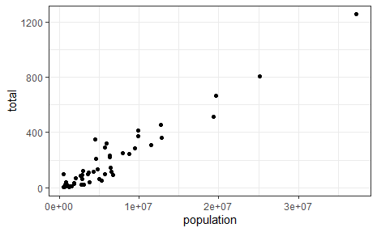

```r
murders %>% ggplot(aes(x = population, y = total)) +
  geom_point()
```

7. Note that if we don’t use argument names, we can obtain the same plot by making sure we enter the variable names in the right order like this:

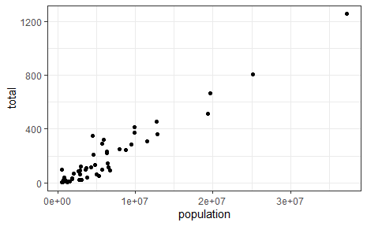

```r
murders %>% ggplot(aes(population, total)) +
  geom_point()
```

Remake the plot but now with total in the x-axis and population in the y-axis.

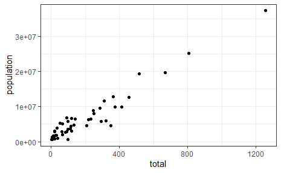

```r
murders %>% ggplot(aes(total, population)) +
  geom_point()
```

8. If instead of points we want to add text, we can use the `geom_text()` or `geom_label()` geometries. The following code

```r
murders %>% ggplot(aes(population, total)) +
  geom_label()
```

will give us the error message: `Error: geom_label requires the following missing aesthetics: label`

Why is this?

1. We need to map a character to each point through the label argument in `aes`.
2. We need to let `geom_label` know what character to use in the plot.
3. The `geom_label` geometry does not require x-axis and y-axis values.
4. `geom_label` is not a ggplot2 command.

**Answer: A**

9. Rewrite the code above to abbreviation as the label through `aes`

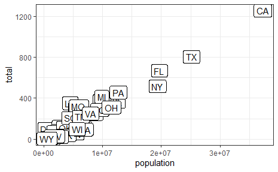

10. Change the color of the labels through blue. How will we do this?
1. Adding a column called blue to murders
2. Because each label needs a different color we map the colors through aes
3. Use the color argument in ggplot
4. Because we want all colors to be blue, we do not need to map colors, just use the color argument in geom_label

**Answer: D**

11. Rewrite the code above to make the labels blue.

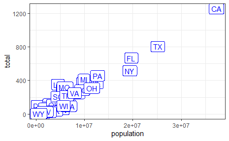

```r
murders %>% ggplot(aes(population, total, label = abb)) +
  geom_label(color = "blue")
```

12. Now suppose we want to use color to represent the different regions. In this case which of the following is most appropriate:
1. Adding a column called `color` to `murders` with the color we want to use.
2. Because each label needs a different color we map the colors through the color argument of `aes`.
3. Use the `color` argument in `ggplot`.
4. Because we want all colors to be blue, we do not need to map colors, just use the color argument in `geom_label`.

**Answer: B**

13. Rewrite the code above to make the labels’ color be determined by the state’s region.

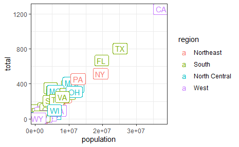

```r
murders %>% ggplot(aes(population, total, label = abb,col = region)) +
  geom_label()
```

14. Now we are going to change the x-axis to a log scale to account for the fact the distribution of population is skewed. Let’s start by define an object `p` holding the plot we have made up to now

```r
p <- murders %>%
  ggplot(aes(population, total, label = abb, color = region)) +
  geom_label()
```

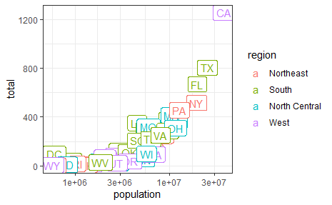

```r
p + scale_x_log10()
```

15. Repeat the previous exercise but now change both axes to be in the log scale.

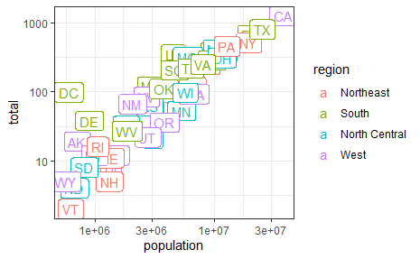

16. Now edit the code above to add the title “Gun murder data” to the plot. Hint: use the ‘ggtitle’ function.

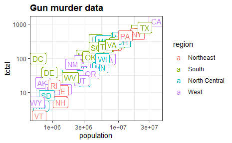